# Bayesian modeling and prediction for movies

## Setup

### Load packages

```r
library(ggplot2)
library(dplyr)
library(statsr)
library(BAS)
```

### Load data

Make sure your data and R Markdown files are in the same directory. When loaded your data file will be called `movies`. Delete this note when before you submit your work.

```r
load("movies.Rdata")
```

## Part 1: Data

The data set contains 651 randomly sampled movie that was produced and released before 2016. We can generalize our conclusions to population, but cannot determine causal relationship since it’s not an experemental set up. * * *

## Part 2: Data manipulation

Variables are criated according to excercise: feature_film

```r
movies <- movies %>% mutate(feature_film = ifelse(title_type=="Feature Film", "Yes", "No"))
```

genre

```r
movies <- movies %>% mutate(drama = ifelse(genre=="Drama", "Yes", "No"))
```

mpaa_rating

```r
movies <- movies %>% mutate(mpaa_rating_R = ifelse(mpaa_rating=="R", "Yes", "No"))
```

oscar_season

```r
movies <- movies %>% mutate(oscar_season = ifelse(thtr_rel_month==10|thtr_rel_month==11|thtr_rel_month==12, "Yes", "No"))
```

summer_season

```r
movies <- movies %>% mutate(summer_season = ifelse(thtr_rel_month==5|thtr_rel_month==6|thtr_rel_month==7|thtr_rel_month==8, "Yes", "No"))
```

## Part 3: Exploratory data analysis

First let’s plot the data.

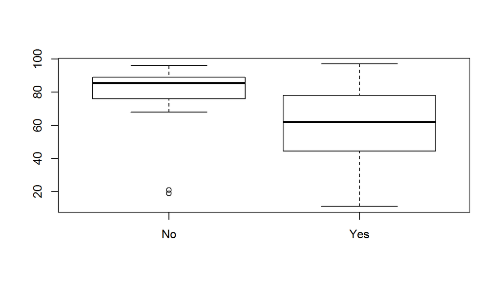

```r
boxplot(movies$audience_score~movies$feature_film)
```

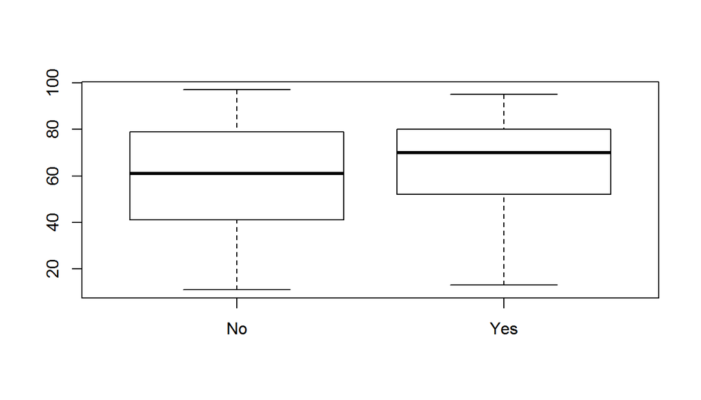

```r
boxplot(movies$audience_score~movies$drama)
```

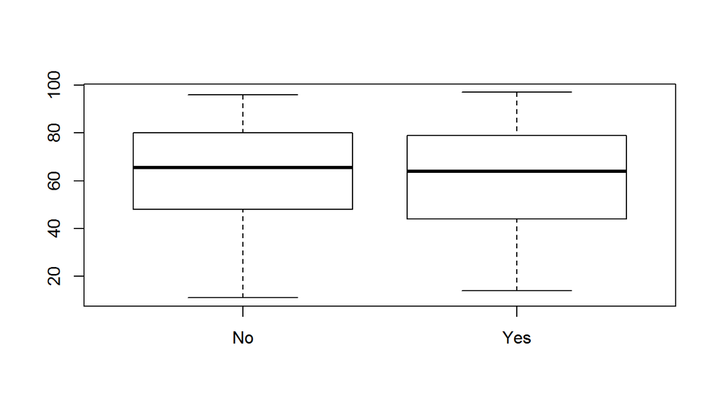

```r
boxplot(movies$audience_score~movies$mpaa_rating_R)
```

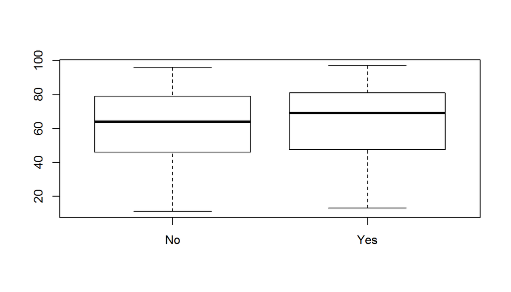

```r
boxplot(movies$audience_score~movies$oscar_season)
```

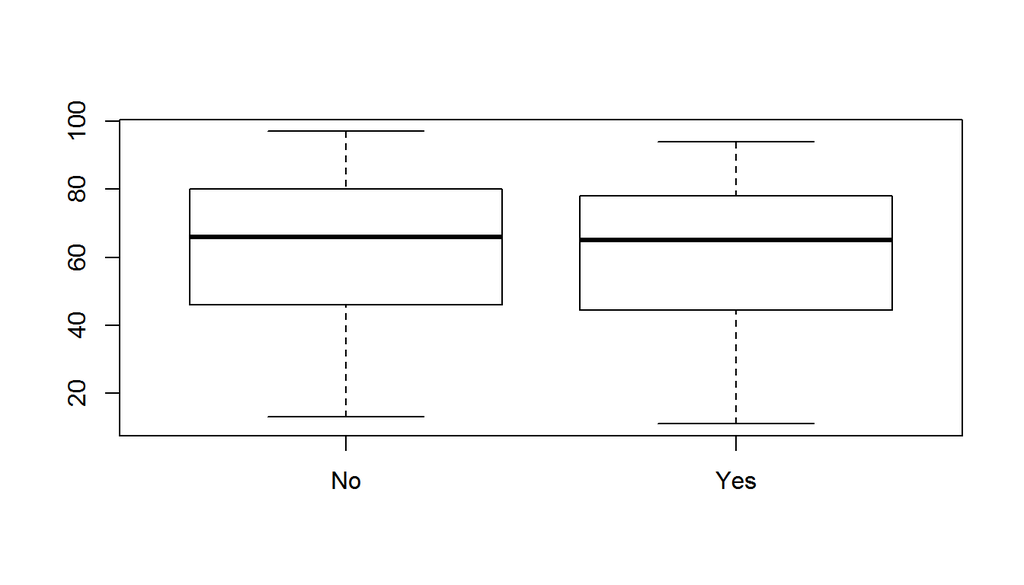

```r
boxplot(movies$audience_score~movies$summer_season)
```

Now we can summarise variables, i decided to do it jointly, since it gives good estimate on how future model should look like.

```r
movies %>% group_by(feature_film, drama, mpaa_rating_R, oscar_season, summer_season) %>% summarise(mean = mean(audience_score), median = median(audience_score))
```

```
## Source: local data frame [21 x 7]
## Groups: feature_film, drama, mpaa_rating_R, oscar_season [?]
##
##    feature_film drama mpaa_rating_R oscar_season summer_season     mean
##           <chr> <chr>         <chr>        <chr>         <chr>    <dbl>
## 1            No    No            No           No            No 84.00000
## 2            No    No            No           No           Yes 82.87500
## 3            No    No            No          Yes            No 82.69231
## 4            No    No           Yes           No            No 78.33333
## 5            No    No           Yes           No           Yes 83.00000
## 6            No    No           Yes          Yes            No 56.00000
## 7            No   Yes            No           No            No 47.00000
## 8            No   Yes           Yes           No            No 86.00000
## 9            No   Yes           Yes           No           Yes 83.00000
## 10          Yes    No            No           No            No 52.29167
## # ... with 11 more rows, and 1 more variables: median <dbl>
```

## Part 4: Modeling

Complete model as required tested by BIC and AIC

```r
full_model_BIC = bas.lm(audience_score ~ feature_film + drama + runtime + mpaa_rating_R + thtr_rel_year + oscar_season + summer_season + imdb_rating + imdb_num_votes + critics_score + best_pic_nom + best_pic_win + best_actor_win + best_actress_win + best_dir_win + top200_box, prior = "BIC", modelprior = uniform(), data = na.omit(movies))
summary(full_model_BIC)
```

```
##      Intercept feature_filmYes dramaYes runtime mpaa_rating_RYes
## [1,]         1               0        0       1                0
## [2,]         1               0        0       0                0
## [3,]         1               0        0       0                0
## [4,]         1               0        0       1                1
## [5,]         1               0        0       1                0
##      thtr_rel_year oscar_seasonYes summer_seasonYes imdb_rating
## [1,]             0               0                0           1
## [2,]             0               0                0           1
## [3,]             0               0                0           1
## [4,]             0               0                0           1
## [5,]             0               0                0           1
##      imdb_num_votes critics_score best_pic_nomyes best_pic_winyes
## [1,]              0             1               0               0
## [2,]              0             1               0               0
## [3,]              0             1               0               0
## [4,]              0             1               0               0
## [5,]              0             1               1               0
##      best_actor_winyes best_actress_winyes best_dir_winyes top200_boxyes
## [1,]                 0                   0               0             0
## [2,]                 0                   0               0             0
## [3,]                 0                   1               0             0
## [4,]                 0                   0               0             0
## [5,]                 0                   0               0             0
##             BF PostProbs     R2 dim   logmarg
## [1,] 1.0000000    0.1558 0.7483   4 -3434.752
## [2,] 0.8715404    0.1358 0.7455   3 -3434.889
## [3,] 0.2048238    0.0319 0.7470   4 -3436.338
## [4,] 0.2039916    0.0318 0.7496   5 -3436.342
## [5,] 0.1851908    0.0289 0.7495   5 -3436.438
```

```r
full_model_AIC = bas.lm(audience_score ~ feature_film + drama + runtime + mpaa_rating_R + thtr_rel_year + oscar_season + summer_season + imdb_rating + imdb_num_votes + critics_score + best_pic_nom + best_pic_win + best_actor_win + best_actress_win + best_dir_win + top200_box, prior = "AIC", modelprior = uniform(), data = na.omit(movies))
summary(full_model_AIC)
```

```
##      Intercept feature_filmYes dramaYes runtime mpaa_rating_RYes
## [1,]         1               0        0       1                1
## [2,]         1               0        0       1                1
## [3,]         1               0        0       1                1
## [4,]         1               0        0       1                1
## [5,]         1               0        0       1                1
##      thtr_rel_year oscar_seasonYes summer_seasonYes imdb_rating
## [1,]             0               0                0           1
## [2,]             1               0                0           1
## [3,]             0               0                0           1
## [4,]             0               0                1           1
## [5,]             1               0                0           1
##      imdb_num_votes critics_score best_pic_nomyes best_pic_winyes
## [1,]              0             1               1               0
## [2,]              0             1               1               0
## [3,]              0             1               1               0
## [4,]              0             1               1               0
## [5,]              0             1               1               0
##      best_actor_winyes best_actress_winyes best_dir_winyes top200_boxyes
## [1,]                 0                   1               0             0
## [2,]                 0                   1               0             0
## [3,]                 1                   1               0             0
## [4,]                 0                   1               0             0
## [5,]                 1                   1               0             0
##             BF PostProbs     R2 dim   logmarg
## [1,] 1.0000000    0.0020 0.7520   7 -3424.229
## [2,] 0.8511260    0.0017 0.7527   8 -3424.390
## [3,] 0.8145471    0.0016 0.7527   8 -3424.434
## [4,] 0.7977079    0.0016 0.7527   8 -3424.455
## [5,] 0.7338948    0.0015 0.7534   9 -3424.538
```

It seems AIC provides slightly better, but more complicated model. Since main purpouse of this excercise is learning we will choose BIC model, due to smaller amount of imput needed. (this will be an advantage for predicting)

```r
full_model_final = bas.lm(audience_score ~ runtime + imdb_rating + critics_score, prior = "BIC", modelprior = uniform(), data = na.omit(movies))
coeffic_final = coefficients(full_model_final)
```

Diagnostic test should be performed.

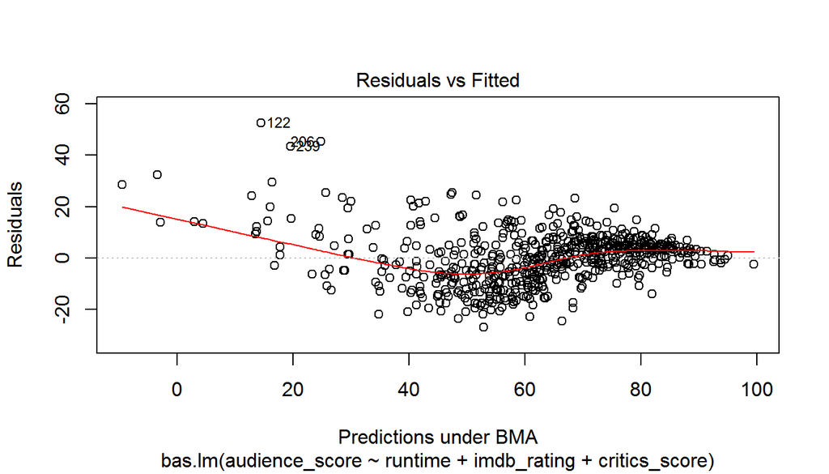

```r
plot(full_model_final, which = 1)
```

## Part 5: Prediction

Now i would like to predict audience score of doctor strange. I checked raiting of the movie on rotten tomatos and created new observation. (remember that i choose simple model, less data to search for)

```r
Dr_strange = data.frame(runtime = 115, imdb_rating = 7.9, critics_score = 90, audience_score = as.vector(89))
```

Now we use predict function,

```r
pred <- predict(full_model_final, Dr_strange, estimator = "BMA", se.fit=TRUE)
```